# SY19, projet 3 : fiabilité de l’heure de départ déclarée (ACN-Data)

Ce notebook relit les résultats produits par les scripts de `src/` (voir `reports/rapport.md` pour l’analyse détaillée et la commande de reproduction). Les modèles longs à ajuster (forêts, SVM, MLP) ne sont pas réentraînés ici : on lit leurs prédictions et métriques sauvegardées dans `reports/preds/` et `reports/metrics/`.

```r
suppressMessages({ library(dplyr); library(knitr) })
source("src/p3_data.R")
fig <- function(f) include_graphics(normalizePath(file.path("reports/figures", f)))
rd  <- function(f) read.csv(file.path("reports/metrics", f))
```

# 1. Question

À l’arrivée, l’usager déclare son heure de départ (`requestedDeparture`). Le simulateur IA04 (Go, LLF sous contrainte de puissance) s’en sert comme échéance. On prédit la probabilité qu’il parte **plus de 15 minutes avant** cette heure, pour savoir quand lui faire confiance.

# 2. Données, cible, déséquilibre

```r
kable(rd("p3_presence.csv"), digits = 3, caption = "Part des sessions avec userID et heure déclarée")
```

Part des sessions avec userID et heure déclarée

| site | sessions | avec_userID | avec_heure_declaree |
| --- | --- | --- | --- |
| caltech | 19610 | 0.669 | 0.669 |
| jpl | 25904 | 0.925 | 0.925 |
| office001 | 1187 | 0.078 | 0.078 |

```r
x <- build_p3()
cat(nrow(x), "sessions retenues,", length(unique(x$userID)), "usagers\n")
```

```
## 35930 sessions retenues, 736 usagers
```

```r
kable(rd("p3_seuils.csv"), digits = 3, caption = "Taux de départ anticipé selon le seuil (min)")
```

Taux de départ anticipé selon le seuil (min)

| seuil_min | taux_anticipe |
| --- | --- |
| 0 | 0.338 |
| 15 | 0.274 |
| 30 | 0.233 |
| 60 | 0.175 |
| 120 | 0.112 |

```r
kable(rd("p3_classes.csv"), digits = 3, caption = "Découpage par date et taux de la classe positive")
```

Découpage par date et taux de la classe positive

| split | sessions | debut | fin | taux_anticipe | usagers |
| --- | --- | --- | --- | --- | --- |
| train | 23539 | 2018-08-31 | 2019-08-31 | 0.254 | 606 |
| val | 6393 | 2019-09-01 | 2019-11-30 | 0.286 | 445 |
| test | 5998 | 2019-12-01 | 2020-02-29 | 0.337 | 437 |

Seuil retenu : 15 min (tolérance de planification, déclarations arrondies ; voir le rapport). Classe positive : un quart à un tiers des sessions, en hausse dans le temps.

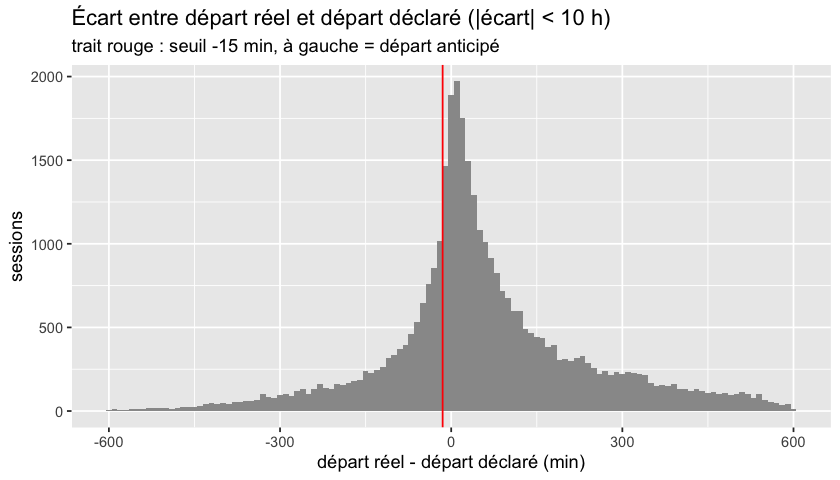

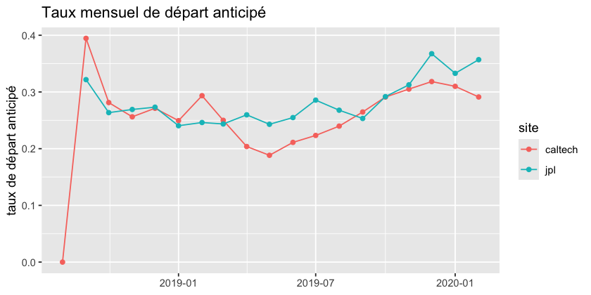

Variables (toutes connues à l’arrivée) : site, arr_hour, dep_hour, dur_decl, weekend, dow, kWhRequested, WhPerMile, n_past, past_rate, past_gap. L’historique de l’usager n’utilise que ses sessions déjà terminées (`tests/test_p3_data.R`).

```r
x %>% group_by(split) %>% summarise(n_past_median = median(n_past), past_rate_moyen = mean(past_rate)) %>% kable(digits = 3)
```

| split | n_past_median | past_rate_moyen |
| --- | --- | --- |
| train | 37 | 0.255 |
| val | 87 | 0.257 |
| test | 97 | 0.279 |

# 3. Protocole

Hyperparamètres par CV (ou OOB, REML, hold-out temporel) sur le train ; seuil de décision maximisant le F1 sur la validation (sept.-nov. 2019) ; résultats sur le test (déc. 2019 - fév. 2020) ; sélection sur l’AUC de validation.

# 4. Modèles

## Baselines, logistique, lasso

```r
kable(rd("p3_logit_coefs.csv"), digits = 3, caption = "Logistique (variables standardisées)")
```

Logistique (variables standardisées)

| variable | Estimate | Std..Error | z.value | Pr…z.. |
| --- | --- | --- | --- | --- |
| (Intercept) | -1.361 | 0.019 | -72.547 | 0.000 |
| sitejpl | 0.044 | 0.018 | 2.354 | 0.019 |
| arr_hour | 0.572 | 0.022 | 26.322 | 0.000 |
| dep_hour | 0.272 | 0.018 | 15.136 | 0.000 |
| dur_decl | 0.613 | 0.023 | 27.137 | 0.000 |
| weekend | 0.136 | 0.016 | 8.269 | 0.000 |
| kWhRequested | -0.027 | 0.018 | -1.536 | 0.125 |
| WhPerMile | -0.044 | 0.017 | -2.570 | 0.010 |
| log1p.n_past. | -0.074 | 0.017 | -4.314 | 0.000 |
| past_rate | 0.704 | 0.022 | 32.639 | 0.000 |
| past_gap | -0.044 | 0.024 | -1.857 | 0.063 |

```r
kable(rd("p3_lasso_coefs.csv"), digits = 3, caption = "Lasso : coefficients à lambda 1-SE et lambda min")
```

Lasso : coefficients à lambda 1-SE et lambda min

| variable | coef_lambda_1se | coef_lambda_min |
| --- | --- | --- |
| (Intercept) | -1.276 | -1.354 |
| sitejpl | 0.000 | 0.036 |
| arr_hour | 0.417 | 0.559 |
| dep_hour | 0.220 | 0.269 |
| dur_decl | 0.433 | 0.598 |
| weekend | 0.061 | 0.130 |
| kWhRequested | 0.000 | -0.018 |
| WhPerMile | 0.000 | -0.040 |
| log1p(n_past) | -0.023 | -0.070 |
| past_rate | 0.672 | 0.701 |
| past_gap | 0.000 | -0.040 |

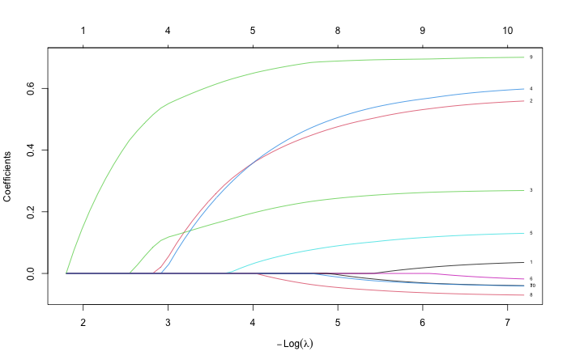

## GAM logistique

```r
kable(rd("p3_gam_termes.csv"), digits = 3, caption = "Termes lisses du GAM")
```

Termes lisses du GAM

| terme | edf | Ref.df | Chi.sq | p.value |
| --- | --- | --- | --- | --- |
| s(arr_hour) | 9.286 | 18 | 230.719 | 0 |
| s(dep_hour) | 10.599 | 18 | 647.148 | 0 |
| s(dur_decl) | 7.169 | 9 | 252.006 | 0 |
| s(past_rate) | 5.319 | 9 | 565.958 | 0 |
| s(lnp) | 2.858 | 5 | 49.044 | 0 |
| s(past_gap) | 3.638 | 5 | 29.334 | 0 |

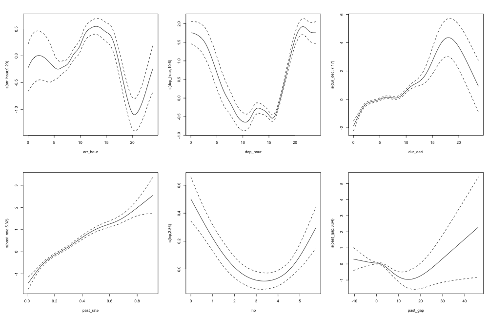

## Arbres et forêts

```r
kable(rd("p3_rf_grille.csv"), digits = 4, caption = "Grille random forest / bagging (AUC out-of-bag, train)")
```

Grille random forest / bagging (AUC out-of-bag, train)

| mtry | nodesize | auc_oob |
| --- | --- | --- |
| 2 | 1 | 0.8405 |
| 3 | 1 | 0.8374 |
| 5 | 1 | 0.8370 |
| 10 | 1 | 0.8339 |
| 2 | 20 | 0.8388 |
| 3 | 20 | 0.8385 |
| 5 | 20 | 0.8378 |
| 10 | 20 | 0.8353 |
| 2 | 50 | 0.8312 |
| 3 | 50 | 0.8309 |
| 5 | 50 | 0.8325 |
| 10 | 50 | 0.8306 |

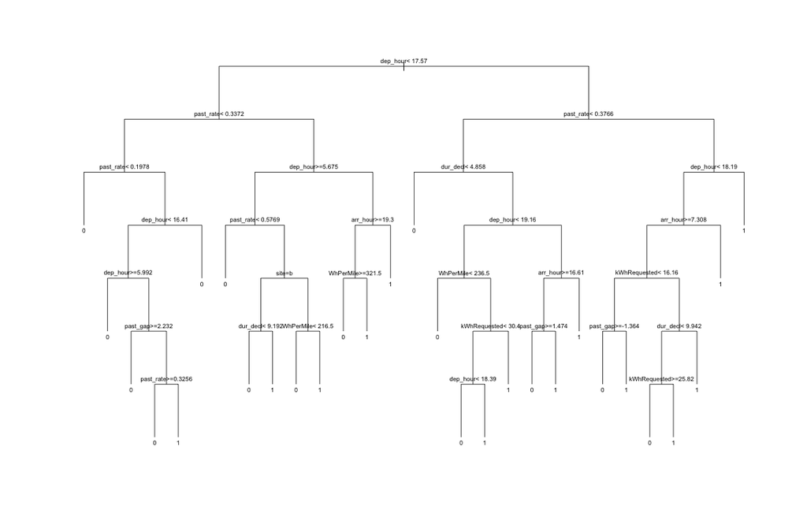

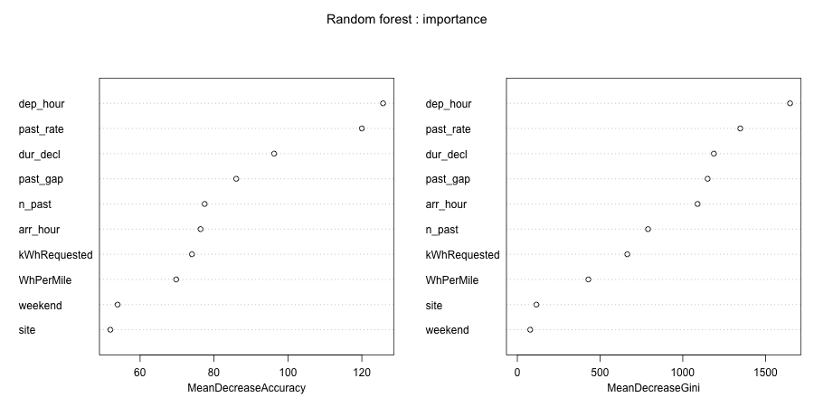

## SVM

```r
kable(rd("p3_svm_grille.csv"), digits = 4, caption = "AUC en CV 3 plis (8 000 sessions du train)")
```

AUC en CV 3 plis (8 000 sessions du train)

| noyau | gamma | cost | auc_cv |
| --- | --- | --- | --- |
| lineaire | NA | 0.01 | 0.7863 |
| lineaire | NA | 0.10 | 0.7870 |
| lineaire | NA | 1.00 | 0.7870 |
| lineaire | NA | 10.00 | 0.7870 |
| rbf | 0.003 | 0.30 | 0.7854 |
| rbf | 0.003 | 1.00 | 0.7897 |
| rbf | 0.003 | 3.00 | 0.7927 |
| rbf | 0.003 | 10.00 | 0.7875 |
| rbf | 0.003 | 30.00 | 0.7819 |
| rbf | 0.010 | 0.30 | 0.7905 |
| rbf | 0.010 | 1.00 | 0.7861 |
| rbf | 0.010 | 3.00 | 0.7807 |
| rbf | 0.010 | 10.00 | 0.7762 |
| rbf | 0.010 | 30.00 | 0.7735 |
| rbf | 0.030 | 0.30 | 0.7797 |
| rbf | 0.030 | 1.00 | 0.7743 |
| rbf | 0.030 | 3.00 | 0.7773 |
| rbf | 0.030 | 10.00 | 0.7787 |
| rbf | 0.030 | 30.00 | 0.7792 |
| rbf | 0.100 | 0.30 | 0.7772 |
| rbf | 0.100 | 1.00 | 0.7805 |
| rbf | 0.100 | 3.00 | 0.7800 |
| rbf | 0.100 | 10.00 | 0.7730 |
| rbf | 0.100 | 30.00 | 0.7686 |
| rbf | 0.300 | 0.30 | 0.7794 |
| rbf | 0.300 | 1.00 | 0.7772 |
| rbf | 0.300 | 3.00 | 0.7746 |
| rbf | 0.300 | 10.00 | 0.7771 |
| rbf | 0.300 | 30.00 | 0.7708 |

## MLP (torch)

```r
kable(rd("p3_mlp_grille.csv"), digits = 4, caption = "Hold-out = 20 % les plus récents du train")
```

Hold-out = 20 % les plus récents du train

| h | wd | auc_holdout | epoques |
| --- | --- | --- | --- |
| 16 | 0.000 | 0.8250 | 95 |
| 64 | 0.000 | 0.8355 | 96 |
| 16 | 0.001 | 0.8224 | 84 |
| 64 | 0.001 | 0.8317 | 96 |

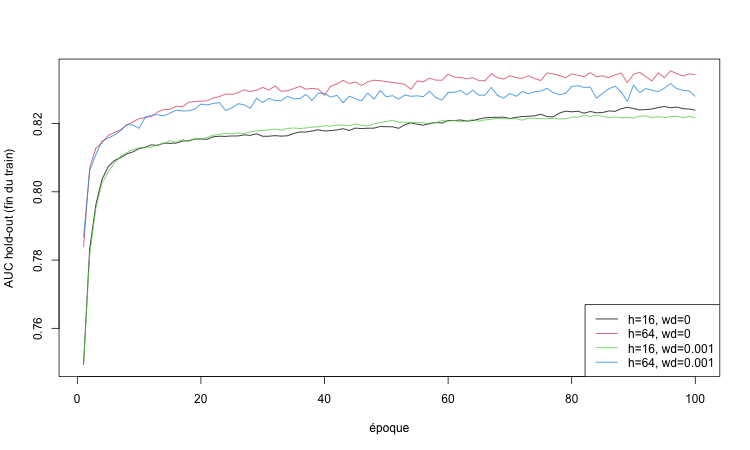

# 5. Comparaison

```r
cmp <- rd("p3_comparaison.csv")
kable(cmp[, c("modele", "auc_val", "auc_test", "auc_test_ic_bas", "auc_test_ic_haut", "f1_val", "f1_test",
              "precision_test", "recall_test", "brier_test", "seuil")], digits = 3)
```

| modele | auc_val | auc_test | auc_test_ic_bas | auc_test_ic_haut | f1_val | f1_test | precision_test | recall_test | brier_test | seuil |
| --- | --- | --- | --- | --- | --- | --- | --- | --- | --- | --- |
| mlp | 0.852 | 0.865 | 0.856 | 0.875 | 0.666 | 0.707 | 0.692 | 0.724 | 0.140 | 0.291 |
| random_forest | 0.848 | 0.861 | 0.851 | 0.871 | 0.674 | 0.707 | 0.751 | 0.667 | 0.138 | 0.410 |
| gam | 0.845 | 0.857 | 0.847 | 0.867 | 0.651 | 0.702 | 0.661 | 0.748 | 0.144 | 0.264 |
| bagging | 0.836 | 0.848 | 0.837 | 0.858 | 0.662 | 0.695 | 0.675 | 0.717 | 0.142 | 0.394 |
| logistique | 0.820 | 0.832 | 0.822 | 0.843 | 0.622 | 0.666 | 0.626 | 0.713 | 0.162 | 0.253 |
| svm_lineaire | 0.820 | 0.833 | 0.822 | 0.843 | 0.623 | 0.668 | 0.639 | 0.699 | 0.161 | 0.266 |
| lda | 0.818 | 0.830 | 0.819 | 0.840 | 0.619 | 0.670 | 0.605 | 0.751 | 0.163 | 0.225 |
| lasso | 0.818 | 0.830 | 0.819 | 0.840 | 0.620 | 0.665 | 0.620 | 0.717 | 0.164 | 0.262 |
| svm_rbf | 0.810 | 0.826 | 0.814 | 0.838 | 0.639 | 0.692 | 0.697 | 0.687 | 0.159 | 0.248 |
| arbre | 0.801 | 0.811 | 0.800 | 0.823 | 0.614 | 0.660 | 0.565 | 0.794 | 0.157 | 0.211 |
| qda | 0.794 | 0.811 | 0.800 | 0.822 | 0.606 | 0.649 | 0.589 | 0.722 | 0.201 | 0.120 |
| taux_usager | 0.747 | 0.762 | 0.750 | 0.775 | 0.543 | 0.606 | 0.522 | 0.722 | 0.184 | 0.250 |
| majoritaire | 0.500 | 0.500 | 0.500 | 0.500 | 0.000 | 0.000 | 0.000 | 0.000 | 0.230 | 0.500 |

```r
kable(rd("p3_confusion_test.csv"), digits = 3, caption = "Matrices de confusion (test, seuil de validation)")
```

Matrices de confusion (test, seuil de validation)

| modele | seuil | tp | fp | fn | tn |
| --- | --- | --- | --- | --- | --- |
| majoritaire | 0.500 | 0 | 0 | 2023 | 3975 |
| taux_usager | 0.250 | 1460 | 1335 | 563 | 2640 |
| logistique | 0.253 | 1442 | 863 | 581 | 3112 |
| lasso | 0.262 | 1450 | 887 | 573 | 3088 |
| lda | 0.225 | 1519 | 990 | 504 | 2985 |
| qda | 0.120 | 1461 | 1021 | 562 | 2954 |
| gam | 0.264 | 1514 | 776 | 509 | 3199 |
| arbre | 0.211 | 1606 | 1236 | 417 | 2739 |
| bagging | 0.394 | 1451 | 700 | 572 | 3275 |
| random_forest | 0.410 | 1350 | 447 | 673 | 3528 |
| svm_lineaire | 0.266 | 1415 | 801 | 608 | 3174 |
| svm_rbf | 0.248 | 1390 | 605 | 633 | 3370 |
| mlp | 0.291 | 1464 | 653 | 559 | 3322 |

[output not shown]

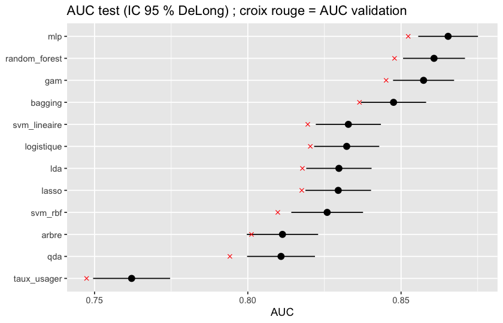

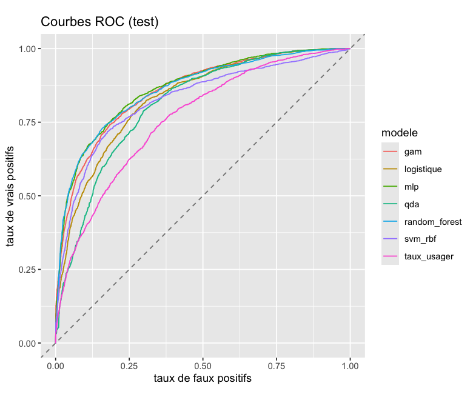

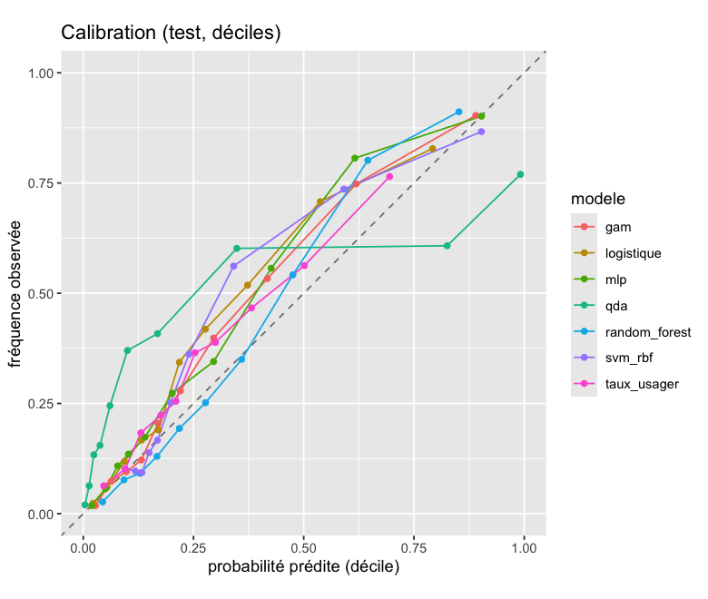

```r
readLines("reports/metrics/p3_selection.csv")
```

[output not shown]

Modèles flexibles (MLP, forêt, GAM) > linéaires (logistique, lasso, LDA, SVM linéaire) > arbre seul, QDA > taux historique de l’usager. Tous sous-estiment le risque sur le test (dérive du taux de 25 % à 34 %).

# 6. Investigation originale

## Ancienneté de l’usager

```r
kable(rd("p3_invest_anciennete.csv"), digits = 3)
```

| anc | sessions | taux_anticipe | ecart_abs_median_min | sessions_test | taux_test | auc_modele | auc_taux_usager |
| --- | --- | --- | --- | --- | --- | --- | --- |
| 0 | 737 | 0.365 | 65.517 | 63 | 0.524 | 0.687 | NA |
| 1-4 | 2366 | 0.355 | 68.625 | 221 | 0.452 | 0.790 | 0.678 |
| 5-19 | 6407 | 0.297 | 74.583 | 657 | 0.400 | 0.838 | 0.741 |
| 20-49 | 8497 | 0.279 | 79.483 | 863 | 0.390 | 0.858 | 0.727 |
| 50+ | 17923 | 0.248 | 88.700 | 4194 | 0.308 | 0.871 | 0.775 |

```r
kable(rd("p3_invest_rang_intra_usager.csv"), digits = 3, caption = "Même usager (>= 40 sessions), par rang de session")
```

Même usager (>= 40 sessions), par rang de session

| rang | usagers | sessions | taux_anticipe |
| --- | --- | --- | --- |
| 1-5 | 258 | 1290 | 0.312 |
| 6-10 | 258 | 1290 | 0.295 |
| 11-20 | 258 | 2580 | 0.267 |
| 21-40 | 258 | 5160 | 0.274 |
| 41+ | 257 | 20369 | 0.250 |

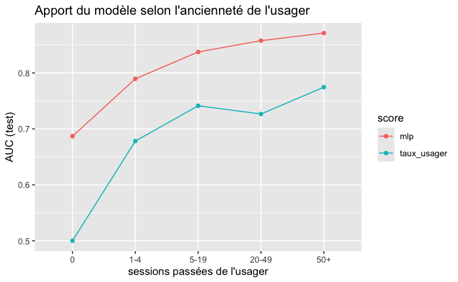

Les habitués sont plus fiables, y compris à l’intérieur d’un même usager ; les nouveaux usagers sont les moins fiables et les plus difficiles à prédire.

## Rééquilibrage des classes

```r
kable(rd("p3_invest_reequilibrage.csv"), digits = 3)
```

| variante | auc_test | f1_test | precision | recall | f1_test_seuil_05 | brier_test | proba_moyenne_test | taux_observe_test | seuil_val |
| --- | --- | --- | --- | --- | --- | --- | --- | --- | --- |
| logistique_aucun | 0.832 | 0.666 | 0.626 | 0.713 | 0.526 | 0.162 | 0.267 | 0.337 | 0.253 |
| logistique_poids | 0.832 | 0.676 | 0.602 | 0.771 | 0.666 | 0.166 | 0.441 | 0.337 | 0.457 |
| logistique_sous_ech | 0.831 | 0.672 | 0.607 | 0.752 | 0.665 | 0.166 | 0.440 | 0.337 | 0.469 |
| rf_aucun | 0.858 | 0.707 | 0.742 | 0.676 | 0.679 | 0.139 | 0.326 | 0.337 | 0.407 |
| rf_sous_ech | 0.864 | 0.714 | 0.728 | 0.700 | 0.717 | 0.144 | 0.418 | 0.337 | 0.527 |

Le rééquilibrage ne change pas l’AUC, améliore le F1 seulement au seuil naïf 0,5 et dégrade la calibration : inutile ici dès que le seuil est choisi sur la validation.

# 7. Module de risque pour IA04

```r
source("src/depart_risk.R")
m <- .dr_model()
cat("AUC test du GAM exporté :", round(m$auc_test, 3), " ; avance médiane si départ anticipé :",
    round(m$avance_mediane_si_anticipe_min, 1), "min\n")
```

```
## AUC test du GAM exporté : 0.858  ; avance médiane si départ anticipé : 89.6 min
```

```r
ex <- data.frame(site = c("jpl", "jpl", "caltech"), arr_hour = c(8, 8, 13), dep_hour = c(17, 23, 18),
                 dur_decl = c(9, 15, 5), weekend = c(0, 0, 1), n_past = c(80, 80, 0),
                 past_rate = c(0.1, 0.1, m$prior$p0), past_gap = c(0.5, 0.5, 0))
ex$p <- depart_risk(newdata = ex); ex$marge_llf_min <- marge_llf(ex$p)
kable(ex, digits = 3)
```

| site | arr_hour | dep_hour | dur_decl | weekend | n_past | past_rate | past_gap | p | marge_llf_min |
| --- | --- | --- | --- | --- | --- | --- | --- | --- | --- |
| jpl | 8 | 17 | 9 | 0 | 80 | 0.100 | 0.5 | 0.116 | 10.360 |
| jpl | 8 | 23 | 15 | 0 | 80 | 0.100 | 0.5 | 0.918 | 82.247 |
| caltech | 13 | 18 | 5 | 1 | 0 | 0.261 | 0.0 | 0.696 | 62.389 |

Exports lisibles depuis Go : `reports/export/depart_risk_gam.json` (tables additives du GAM), `depart_risk_usagers.csv` (historique par usager), `depart_risk_creneaux.csv` (probabilités par créneau). Dans le LLF : échéance effective = heure déclarée - `marge_llf(p)`.